# Inferring a Rate

Lee & Wagenmakers Part II. 3.1, p37

cn

2023-04-04

# 1 Packages

```r
set.seed(12345)

if (!require("pacman", quietly = TRUE)) install.packages("pacman")
# if (!require("rjags", quietly = TRUE)) install.packages("rjags")
pacman::p_load(cowplot, R2jags, psych)
pacman::p_load_gh("RLesur/klippy")

klippy::klippy()
```

# 2 Graphic model

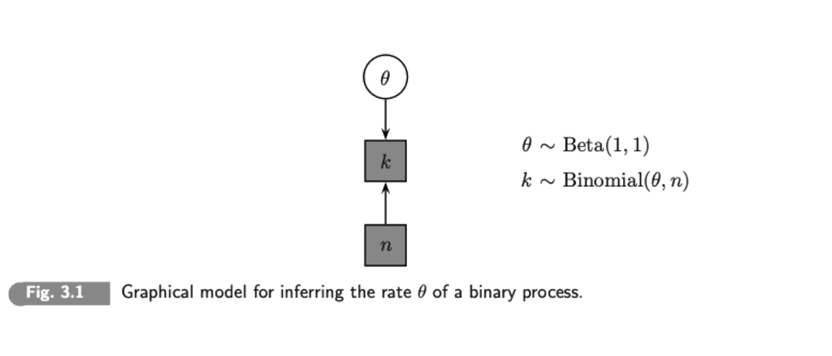

# 3 Running MCMC

## 3.1 Setups

저자들이 제공한 코드 앞부분에는 rjags를 설치할 때 zip 파일을 직접 내려받으라고 써있다. 그러나 이제는 그냥 정상적인 패키지 설치 방법을 사용해도 된다.

```r
# 자료
k <- 5
n <- 10

data <- list("k", "n")

myinits <-  list(
  list(theta = 0.1), # chain 1 starting value
  list(theta = 0.9)) # chain 2 starting value

# 관찰할 파라미터(parameters to be monitored):
parameters <- c("theta")
```

자료와 변수, 초기값, 파라미터를 설정하였다. 이진적 결과가 나오는 10회 시행에서 5번 특정 값이 산출되었다. 이제 해당 반응의 비율 *theta* 파라미터를 두 개의 체인에서 표집해보자.

## 3.2 Model & MCMC

원래 코드에서는 모델을 .txt 파일에 별도로 저장하고, 그 파일을 부르는 방식을 썼다. jags 코드가 길면 그게 편할 거다. 이번 코드는 짧으니까, 아래처럼 모델 코드를 직접 작서하고 `textConnection()`으로 호출할 수 있다(아래 코드는 실행되지 않는다 - 그 아래 코드블럭 참조).

```r
model_text <- "
# Inferring a Rate
model{
   # Prior Distribution for Rate Theta
   theta ~ dbeta(1,1)
   # Observed Counts
   k ~ dbin(theta,n)
}
"
# The following command calls JAGS with specific options.
# For a detailed description see the R2jags documentation.
samples <- jags(data, inits= myinits, parameters,
                                model.file = textConnection(model_text),
                                n.chains=2, n.iter=20000,
                                n.burnin=1, n.thin=1, DIC=T)
```

그러나 모델을 아래처럼 함수 형태로 작성하는 것이 더 편하다. 아래 코드를 실행한다.

```r
# https://rpruim.github.io/Kruschke-Notes/jags-just-another-gibbs-sampler.html
# 더 간단한 코드
mymodel <- function() {
  theta ~ dbeta(1,1)
  k ~ dbin(theta, n)
}

samples <- jags(data = list(k = k, n = n),
                inits = myinits,
                parameters.to.save = parameters,
                model.file = mymodel,
                n.chains = 2, n.iter = 20000, n.burnin = 1, n.thin = 1,
                jags.module = c("dic")
                )
```

`jags()`에 인수로 들어가는 옵션들은 `?jags`를 콘솔에 입력하여 확인할 수 있다: 여기에서는 2만개의 표본을 생성하였다. 처음 한 개의 표본은 버리고(`burnin`) 매번 생성되는 표본을 모두 저장하였다(`thin`). 이제 관찰한 파라미터의 값들이 **samples** 객체에 저장되었으니 자세히 살펴보자.

# 4 Visualization

정보가 풍부할수록 자료를 시각화하는 기술이 중요하다. 베이지안 분석은 분포 추정이므로 빈도주의 점 추정보다 많은 정보를 제공한다. 따라서 mcmc 표본을 정리하고 그림으로 보여주는 기법/패키지가 개발되어 왔다.

저자들이 제공한 코드는 mcmc 표본을 읽거나 시각화할 때 가급적 기타 패키지를 사용하지 않도록 작성된 듯 하다. 따라서 먼저 그 코드를 실행해보고, 최신 패키지의 기능은 그 후에 살펴보기로 한다.

## 4.1 Raw codes

```r
print(samples)
```

```
## Inference for Bugs model at "/var/folders/q0/7hh9cyp12fl453gbm_1gft200000gn/T//RtmpDR3O2n/modelc7e784c39f3.txt", fit using jags,
##  2 chains, each with 20000 iterations (first 1 discarded)
##  n.sims = 39998 iterations saved
##          mu.vect sd.vect  2.5%   25%   50%   75% 97.5%  Rhat n.eff
## theta      0.501   0.140 0.232 0.401 0.501 0.602 0.769 1.001 40000
## deviance   3.691   1.253 2.805 2.896 3.215 3.980 7.277 1.001  7500
##
## For each parameter, n.eff is a crude measure of effective sample size,
## and Rhat is the potential scale reduction factor (at convergence, Rhat=1).
##
## DIC info (using the rule, pD = var(deviance)/2)
## pD = 0.8 and DIC = 4.5
## DIC is an estimate of expected predictive error (lower deviance is better).
```

`print()`는 인수의 자료형에 따라 적절하게 요약된 결과를 제시한다. 위에서 2개의 체인으로부터 4만 번 표집을 했고 처음 표본을 버렸으니 `n.sims = 39998`이 된다. *theta*가 관찰한 파라미터이다. 39998개의 표본의 분포가 요약되어 있다. *deviance*는 모형의 적합도를 표현하는 통계량으로서, 모형 선택 시 활용된다. 체인의 수렴 정도를 보여주는 **R-hat** 즉, $\hat{R}$이 1.1보다 작은지 확인해야 한다.

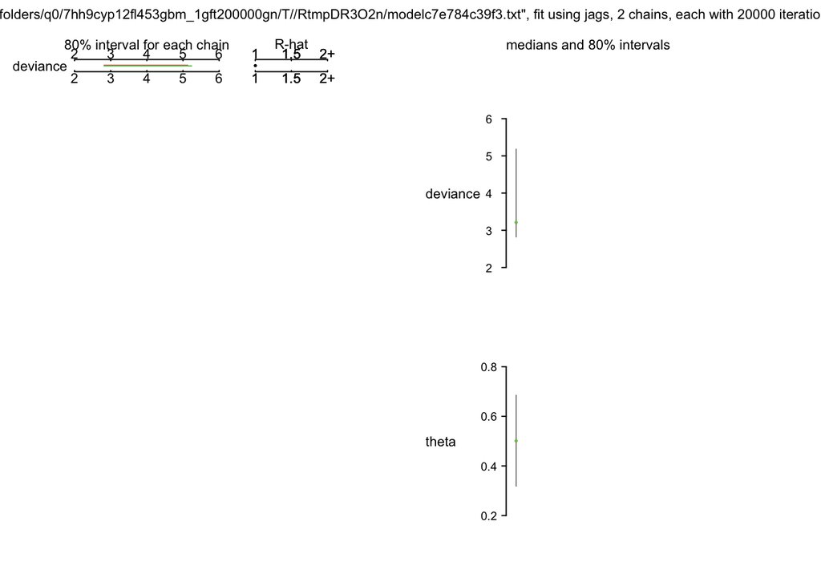

```r
plot(samples)
```

`plot()`은 주요 결과를 요약해서 보여주는데, 보기가 좋지는 않다.

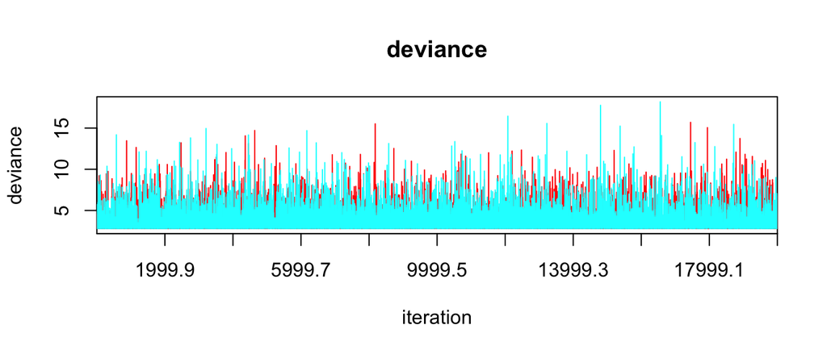

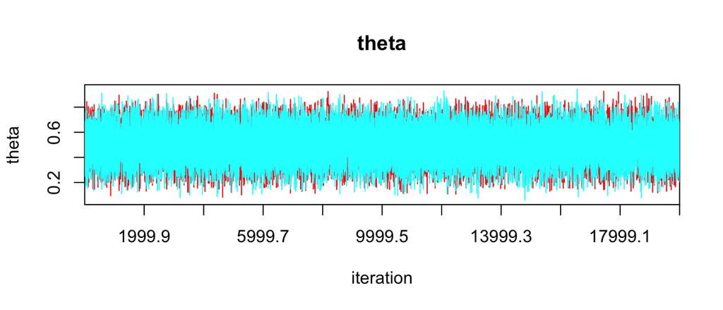

```r
traceplot(samples)
```

트레이스 플롯은 송충이(caterpillar) 모양으로 나와야 한다. 송충이 플롯이라고도 부른다.

**samples** 객체의 내용을 보려면 아래 방법을 쓸 수 있다.

```r
summary(samples)
```

```
##                    Length Class  Mode
## model               8     jags   list
## BUGSoutput         24     bugs   list
## parameters.to.save  2     -none- character
## model.file          1     -none- character
## n.iter              1     -none- numeric
## DIC                 1     -none- logical
```

```r
summary(samples$BUGSoutput)
```

```
##                 Length Class  Mode
## n.chains            1  -none- numeric
## n.iter              1  -none- numeric
## n.burnin            1  -none- numeric
## n.thin              1  -none- numeric
## n.keep              1  -none- numeric
## n.sims              1  -none- numeric
## sims.array      79996  -none- numeric
## sims.list           2  -none- list
## sims.matrix     79996  -none- numeric
## summary            18  -none- numeric
## mean                2  -none- list
## sd                  2  -none- list
## median              2  -none- list
## root.short          2  -none- character
## long.short          2  -none- list
## dimension.short     2  -none- numeric
## indexes.short       2  -none- list
## last.values         2  -none- list
## program             1  -none- character
## model.file          1  -none- character
## isDIC               1  -none- logical
## DICbyR              1  -none- logical
## pD                  1  -none- numeric
## DIC                 1  -none- numeric
```

```r
samples$BUGSoutput$sims.array[1:15,,2] # array: sample, chain, parameter
```

```
##            [,1]      [,2]
##  [1,] 0.3520050 0.6878145
##  [2,] 0.3016038 0.3593254
##  [3,] 0.4561912 0.4306034
##  [4,] 0.3802150 0.5230764
##  [5,] 0.6508161 0.2747164
##  [6,] 0.4409815 0.5179605
##  [7,] 0.4389619 0.6186076
##  [8,] 0.5594222 0.3784760
##  [9,] 0.5209133 0.3796212
## [10,] 0.4331679 0.4000996
## [11,] 0.3616460 0.4822246
## [12,] 0.4767888 0.2486407
## [13,] 0.4329636 0.3997032
## [14,] 0.4145393 0.6108526
## [15,] 0.5615298 0.6754967
```

위 코드에서 `sims.array[1:15,,2]`는 모든 체인의 두 번째 파라미터(*theta*인 듯) 표본에서 처음 15개를 말한다.

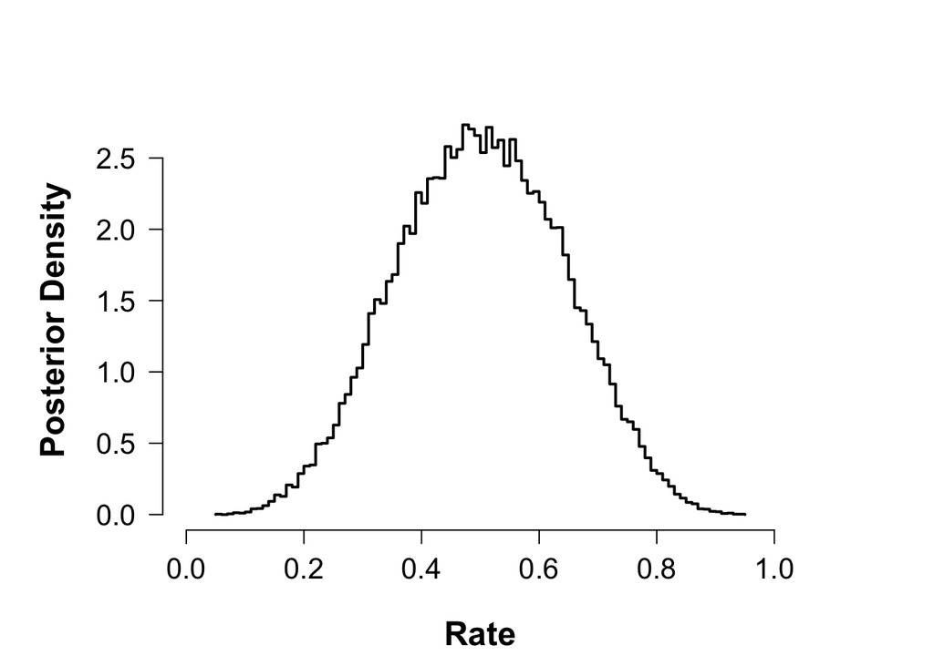

```r
theta <- samples$BUGSoutput$sims.list$theta

par(cex.main = 1.5, mar = c(5, 6, 4, 5) + 0.1, mgp = c(3.5, 1, 0), cex.lab = 1.5,
    font.lab = 2, cex.axis = 1.3, bty = "n", las=1)
Nbreaks <- 80
y       <- hist(theta, Nbreaks, plot=F)
plot(c(y$breaks, max(y$breaks)), c(0,y$density,0), type="S", lwd=2, lty=1,
     xlim=c(0,1), xlab="Rate", ylab="Posterior Density")
```

다루기 쉽도록, 파라미터의 사후분포 표본(posterior samples)를 *theta*라는 변수에 넣고 사후분포를 그렸다.

```r
samples.mcmc <- as.mcmc(samples)
xyplot(samples.mcmc)
densityplot(samples.mcmc)
```

위 코드의 플롯 함수들은 예전에 작동했지만, 지금은 작동하지 않는다. 별로 도움이 안될 것 같으니 생략한다.

## 4.2 CalvinBayes

표집한 결과를 쉽게 다룰 수 있는 함수들을 제공한다. 활용 사례는 [여기](https://rpruim.github.io/Kruschke-Notes/jags-just-another-gibbs-sampler.html)를 참조할 것.

```r
pacman::p_load_gh("rpruim/CalvinBayes")
headTail(posterior(samples))
```

```
##       deviance theta   chain  iter
## 1         3.72  0.35 chain:1     1
## 2         4.52   0.3 chain:1     2
## 3         2.88  0.46 chain:1     3
## 4          3.4  0.38 chain:1     4
## ...        ...   ...    <NA>   ...
## 39995     2.84  0.47 chain:2 19996
## 39996     2.81  0.51 chain:2 19997
## 39997     2.84  0.53 chain:2 19998
## 39998     2.99  0.43 chain:2 19999
```

`posterior()`는 모든 체인의 표본을 추출하여 data.frame으로 정리해준다.

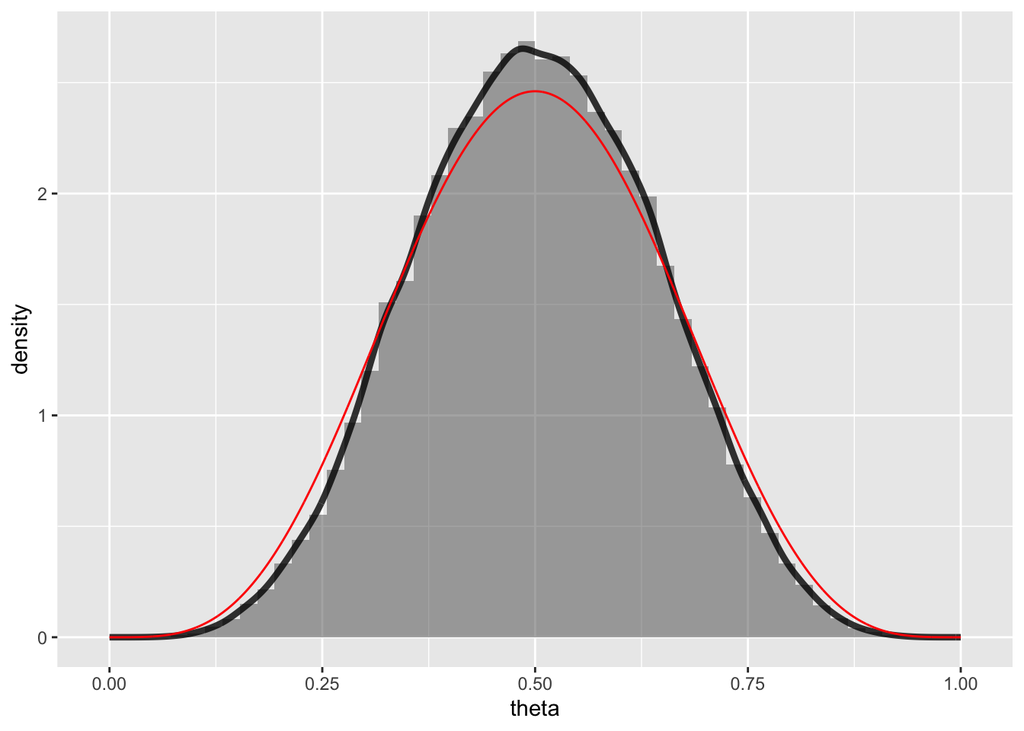

```r
gf_dhistogram(~theta, data = posterior(samples), bins = 50) %>%
    gf_dens(~theta, size = 1.5, alpha = 0.8) %>%
    gf_dist("beta", shape1 = 5, shape2 = 5, color = "red")
```

사후분포를 `ggplot` 유형의 밀도함수로 그릴 수 있다.

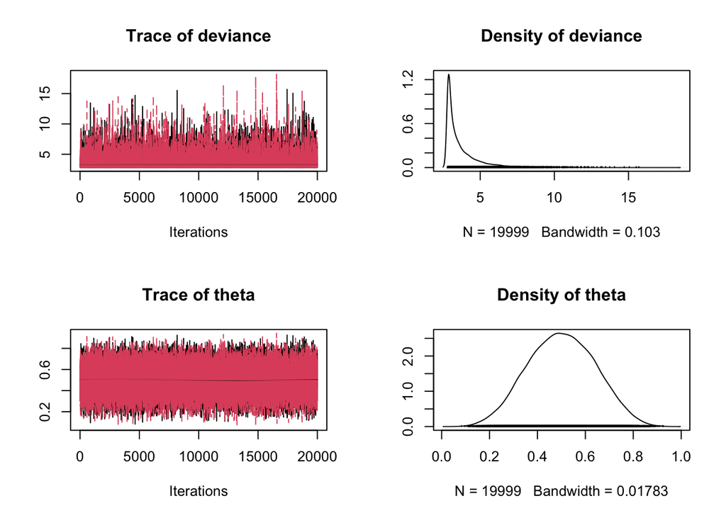

```r
samples.mcmc <- as.mcmc(samples)
plot(samples.mcmc)
```

`as.mcmc()`로 자료유형을 변환하면 `plot()`으로 표집 결과를 훨씬 간편하게 확인할 수 있다.

## 4.3 bayesplot

또 하나의 유용한 패키지이다. 활용 사례는 [여기](https://mc-stan.org/bayesplot/)를 참조할 것.

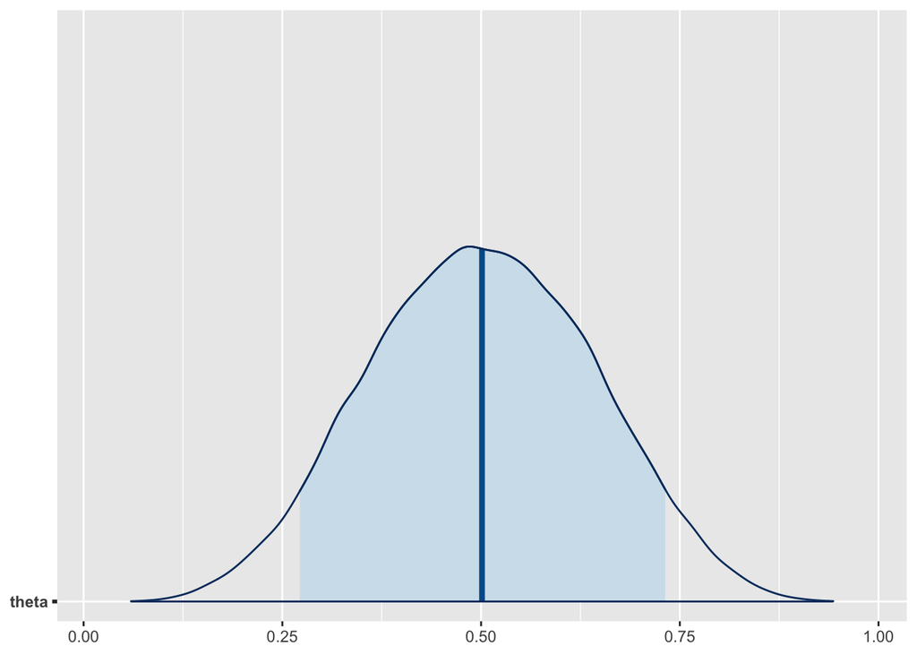

```r
library(bayesplot)
mcmc_areas(
    samples,
    pars = c("theta"),
    prob = 0.90)
```

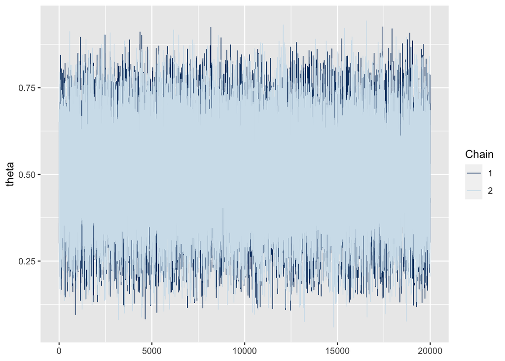

```r
mcmc_trace(samples.mcmc, pars = "theta")
```

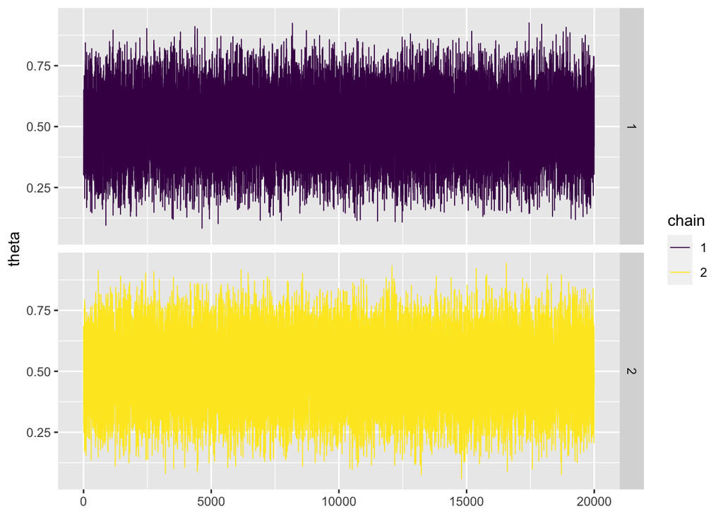

```r
mcmc_trace(samples.mcmc, pars = "theta") %>%
    gf_facet_grid( chain ~ .) %>%
    gf_refine(scale_color_viridis_d())
```

Trace를 겹쳐서 그릴 수도 있고, 체인별로 나눠서 그릴 수도 있다.

다래는 연습문제 3.1.2를 위한 코드이다.

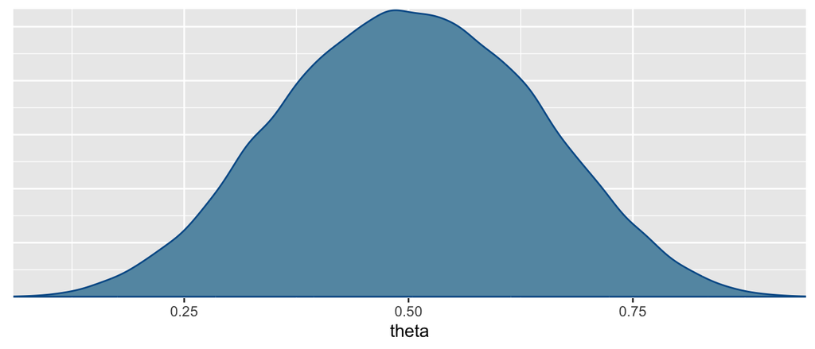

```r
mcmc_dens(samples, pars = c("theta"))
```

```r
# see https://stackoverflow.com/questions/43862665/exact-kernel-density-value-for-any-point-in-r
dens.theta <- density(posterior(samples)$theta)
approx(dens.theta$x, dens.theta$y, xout = c(0.5, .7))
```

```
## $x
## [1] 0.5 0.7
##
## $y
## [1] 2.638213 1.165981
```

# 5 Bernoulli trials

열 번의 시행을 합치지 않고 개별 시행을 그대로 입력하는 방법도 있다. 개별 시행은 베르누이 분포를 따른다.

```r
# https://rpruim.github.io/Kruschke-Notes/jags-just-another-gibbs-sampler.html
y <- c(0,1,1,0,0,1,1,0,0,1)

bern_model <- function() {
  for (i in 1:N) {
    y[i] ~ dbern(theta)
  }
  theta ~ dbeta(1,1)
}

bern_jags <-
  jags(
    data = list(y = y, N = length(y)),
    inits = myinits,
    parameters.to.save = parameters,
    model.file = bern_model,
    n.chains = 2,
    n.iter = 20000,
    n.burnin = 1,
    n.thin = 1,
    jags.module = c("dic")
  )
bern_jags
```

```
## Inference for Bugs model at "/var/folders/q0/7hh9cyp12fl453gbm_1gft200000gn/T//RtmpDR3O2n/modelc7e20cd2b90.txt", fit using jags,
##  2 chains, each with 20000 iterations (first 1 discarded)
##  n.sims = 39998 iterations saved
##          mu.vect sd.vect   2.5%    25%    50%    75%  97.5%  Rhat n.eff
## theta      0.500   0.139  0.233  0.402  0.499  0.600  0.768 1.001 40000
## deviance  14.741   1.244 13.864 13.952 14.263 15.023 18.273 1.001 40000
##
## For each parameter, n.eff is a crude measure of effective sample size,
## and Rhat is the potential scale reduction factor (at convergence, Rhat=1).
##
## DIC info (using the rule, pD = var(deviance)/2)
## pD = 0.8 and DIC = 15.5
## DIC is an estimate of expected predictive error (lower deviance is better).
```

# 6 Session Info

```r
sessionInfo()
## R version 4.2.3 (2023-03-15)
## Platform: aarch64-apple-darwin20 (64-bit)
## Running under: macOS Ventura 13.3
##
## Matrix products: default
## BLAS:   /Library/Frameworks/R.framework/Versions/4.2-arm64/Resources/lib/libRblas.0.dylib
## LAPACK: /Library/Frameworks/R.framework/Versions/4.2-arm64/Resources/lib/libRlapack.dylib
##
## locale:
## [1] en_US.UTF-8/en_US.UTF-8/en_US.UTF-8/C/en_US.UTF-8/en_US.UTF-8
##
## attached base packages:
## [1] stats     graphics  grDevices utils     datasets  methods   base
##
## other attached packages:
##  [1] CalvinBayes_0.2.6 bayesplot_1.10.0  ggformula_0.10.2  ggridges_0.5.4
##  [5] scales_1.2.1      ggstance_0.3.6    ggplot2_3.4.2     dplyr_1.1.1
##  [9] klippy_0.0.0.9500 psych_2.3.3       R2jags_0.7-1      rjags_4-13
## [13] coda_0.19-4       cowplot_1.1.1     pacman_0.5.1
##
## loaded via a namespace (and not attached):
##   [1] colorspace_2.1-0     ellipsis_0.3.2       brms_2.19.0
##   [4] markdown_1.5         base64enc_0.1-3      rstudioapi_0.14
##   [7] farver_2.1.1         rstan_2.21.8         DT_0.27
##  [10] fansi_1.0.4          mvtnorm_1.1-3        codetools_0.2-19
##  [13] bridgesampling_1.1-2 mnormt_2.1.1         cachem_1.0.7
##  [16] knitr_1.42           shinythemes_1.2.0    polyclip_1.10-4
##  [19] jsonlite_1.8.4       broom_1.0.4          ggforce_0.4.1
##  [22] shiny_1.7.4          compiler_4.2.3       backports_1.4.1
##  [25] assertthat_0.2.1     Matrix_1.5-3         fastmap_1.1.1
##  [28] cli_3.6.1            later_1.3.0          tweenr_2.0.2
##  [31] prettyunits_1.1.1    htmltools_0.5.5      tools_4.2.3
##  [34] igraph_1.4.1         gtable_0.3.3         glue_1.6.2
##  [37] reshape2_1.4.4       posterior_1.4.1      Rcpp_1.0.10
##  [40] jquerylib_0.1.4      ggdag_0.2.8          vctrs_0.6.1
##  [43] nlme_3.1-162         crosstalk_1.2.0      tensorA_0.36.2
##  [46] xfun_0.38            stringr_1.5.0        ps_1.7.4
##  [49] mime_0.12            miniUI_0.1.1.1       lifecycle_1.0.3
##  [52] mosaicCore_0.9.2.1   gtools_3.9.4         MASS_7.3-58.3
##  [55] zoo_1.8-11           tidygraph_1.2.3      colourpicker_1.2.0
##  [58] hms_1.1.3            promises_1.2.0.1     Brobdingnag_1.2-9
##  [61] parallel_4.2.3       inline_0.3.19        shinystan_2.6.0
##  [64] yaml_2.3.7           gridExtra_2.3        StanHeaders_2.21.0-7
##  [67] loo_2.6.0            sass_0.4.5           labelled_2.10.0
##  [70] stringi_1.7.12       highr_0.10           dygraphs_1.1.1.6
##  [73] checkmate_2.1.0      pkgbuild_1.4.0       boot_1.3-28.1
##  [76] rlang_1.1.0          pkgconfig_2.0.3      matrixStats_0.63.0
##  [79] distributional_0.3.2 evaluate_0.20        lattice_0.20-45
##  [82] purrr_1.0.1          labeling_0.4.2       rstantools_2.3.1
##  [85] htmlwidgets_1.6.2    processx_3.8.0       tidyselect_1.2.0
##  [88] plyr_1.8.8           magrittr_2.0.3       R6_2.5.1
##  [91] magick_2.7.4         generics_0.1.3       DBI_1.1.3
##  [94] pillar_1.9.0         haven_2.5.2          withr_2.5.0
##  [97] xts_0.13.0           abind_1.4-5          tibble_3.2.1
## [100] crayon_1.5.2         utf8_1.2.3           rmarkdown_2.21
## [103] grid_4.2.3           callr_3.7.3          forcats_1.0.0
## [106] threejs_0.3.3        digest_0.6.31        xtable_1.8-4
## [109] tidyr_1.3.0          httpuv_1.6.9         RcppParallel_5.1.7
## [112] stats4_4.2.3         munsell_0.5.0        viridisLite_0.4.1
## [115] bslib_0.4.2          shinyjs_2.1.0        R2WinBUGS_2.1-21
```